# Quiz Assignment: Monte-Carlo Integration, Bayesian, Bootstrp Resampling, Importance Sampling, Optimization

Jiangong Li, jli153 (leader) Yifan Sun, yifans8 Yuting Du, yutingd3 Mengyuan Zhang, mz37 Yue Wang, yue18

## Problem 1-Monte-Carlo Integration(Yuting Du):

Write a function use the Monte-Carlo integration to get the integration on [a, b] for arbitray function.

$I(f)=\int_{a}^{b}(f(x))$, arbitrary f. Note: (a,b) is an arbitrary interval, finite or infinite Assume finite.

### 1.1 Use Monte-Carlo integration approach to estimate the integration, standard error and 95% CI:

```r
#Function to be integrated over [a,b]
f <- function(x){x}

Integral <- function(n,a,b,h=f){
u <- runif(n,a,b)
Y <- (h(u))/(1/(b-a))
Int <- mean(Y)

u <- runif(n,a,b)
YY <- (h(u)/(1/(b-a)))^2
SE <- sqrt((mean(YY)-Int^2)/n)
CI <- c(Int-1.96*SE,Int+1.96*SE)
list("Int"=Int,"SE"=SE, "CI"=CI)}
```

### 1.2 Apply the function on both uniform distribution and exponential distribution:

Apply the function on both uniform distribution and exponential distribution.

```r
Integral(1000,0,1,f)
```

```
## $Int
## [1] 0.5025
##
## $SE
## [1] 0.009151
##
## $CI
## [1] 0.4846 0.5205
```

```r
f1 <- function(x){exp(-x)}
Integral(1000,0,10,f1)
```

```
## $Int
## [1] 1.129
##
## $SE
## [1] 0.06422
##
## $CI
## [1] 1.003 1.255
```

### 1.3 Reference:

[Monte Carlo Integration](https://cran.r-project.org/web/packages/SI/vignettes/my-vignette.html)

## Problem 2-Bayesian applications of Monte-Carlo (Mengyuan Zhang):

Let $X_1, X_2,...,X_n$ be i.i.d. from $N(\theta, 1)$, where $\theta$ is unknown. In Bayesian inference, we may put a Cauchy prior distribution on $\theta$, and the Bayes estimate of $\theta$ is the mean of the posterior distribution:
$$\pi(\theta|x_1,x_2,...,x_n)\propto \frac{1}{\pi(1+\theta^2)}\prod_{i=1}^{n} \frac{1}{\sqrt{2\pi}} e^{-(x_i-\theta)^2 / 2}$$
Suppose $n=5$ and the observed values are $x_1 = 1.6, x_2 = 0.6, x_3 = -0.7, x_4 = 1.1, x_5 = 0.8$. Design a sampling algorithm to generate 1000 samples from $\pi(\theta|x_1 = 1.6, x_2 = 0.6, x_3 = -0.7, x_4 = 1.1, x_5 = 0.8)$.

The target posterior distribution is
$$\pi(\theta|x_1,x_2,...,x_n)\propto\frac{1}{\pi(1+\theta^2)}\prod_{i=1}^{n} \frac{1}{\sqrt{2\pi}} e^{-(x_i-\theta)^2 / 2}$$
$$\propto \frac{1}{\pi(1+\theta^2)}e^{-\sum_{i=1}^{n}-(x_i-\theta)^2 / 2}$$

$$\propto \frac{1}{\pi(1+\theta^2)}e^{-\sum_{i=1}^{n}-(x_i-\bar x+\bar x -\theta)^2 / 2}$$

$$\propto \frac{1}{1+\theta^2}e^{-n(\bar x-\theta)^2/2}$$

$$\propto \frac{1}{1+\theta^2}\frac{1}{\sqrt{2\pi/n}}e^{-\frac{(\theta - \bar x)^2}{2/n}}$$

$$\leq \frac{1}{\sqrt{2\pi/n}}e^{-\frac{(\theta - \bar x)^2}{2/n}}$$

$$= N(\bar x, \frac{1}{n})$$

Thus, we can consider $N(\bar x, \frac{1}{n})$ as the instrumental distribution with $c = 1$. The rejection method is as following:  
1. Generate $\theta \sim N(\bar x, \frac{1}{n})$  
2. Generate $u \sim Uniform(0, 1)$  
3. Accept x if $u \leq \frac{1}{1 + \theta^2}$

### 2.1 calculate accept rate, posterior mean, std

```r
set.seed(428)
xbar = mean(c(1.6, 0.6, -0.7, 1.1, 0.8))
n = 1000
Theta = rep(0, n)
accept = 0
total = 0
while(accept < n){
    theta = rnorm(1, xbar, sqrt(1 / 5))
    u = runif(1)
    total = total + 1
    if(u <= 1 / (1 + theta^2)){
        accept = accept + 1
        Theta[accept] = theta
    }
}
# accept rate
accept / total
```

```
## [1] 0.6562
```

```r
# posterior mean
mean(Theta)
```

```
## [1] 0.5684
```

```r
# estimate of sd
sd(Theta) / sqrt(n)
```

```
## [1] 0.01297
```

The acceptance rate is around 65%. The estimated mean of this distribution is 0.57, and the standard error of the estimate is 0.013.

### 2.2 Reference:

The problem comes from the textbook of another course STAT525. The answer was present.

## Problem 3-Bootstrp Resampling (Yifan Sun):

We will now consider the Boston housing data set, from the MASS library. ### 3.1. Based on this data set, provide an estimate for the population mean of medv. Call this estimate $\mu$.

```r
library("MASS")
mu = mean(Boston$medv)
mu
```

```
## [1] 22.53
```

### 3.2. Provide an estimate of the standard error of $\mu$. Interpret this result.

```r
se_mu = sd(Boston$medv)/sqrt(length(Boston$medv))
se_mu
```

```
## [1] 0.4089
```

### 3.3. Now estimate the standard error of $\mu$ using the bootstrap. How does this compare to your answer from (b)?

```r
Tboot = numeric()
for (i in 1:1000) {
  mysample = sample(x = Boston$medv, size = length(Boston$medv), replace = TRUE)
  Tboot[i] = mean(mysample)
}
Tboot_se = sd(Tboot)
Tboot_se
```

```
## [1] 0.4227
```

```r
# Two results are almost same.
```

### 3.4. Based on your bootstrap estimate from (c), provide a 95% confidence interval for the mean of medv. Compare it to the results obtained using t.test(Boston$medv).

```r
mu + c(-1,1)*qnorm(p = 0.975, mean = 0, sd = 1)*Tboot_se
```

```
## [1] 21.70 23.36
```

```r
t.test(Boston$medv)
```

```
##
##  One Sample t-test
##
## data:  Boston$medv
## t = 55, df = 505, p-value <2e-16
## alternative hypothesis: true mean is not equal to 0
## 95 percent confidence interval:
##  21.73 23.34
## sample estimates:
## mean of x
##     22.53
```

```r
# Two confidence intervals are almost same.
```

### 3.5. Based on this data set, provide an estimate, $\mu_{med}$, for the median value of medv in the population.

```r
mu_med = median(Boston$medv)
mu_med
```

```
## [1] 21.2
```

### 3.6. We now would like to estimate the standard error of $\mu_{med}$. Unfortunately, there is no simple formula for computing the standard error of the median. Instead, estimate the standard error of the median using the bootstrap. Comment on your findings.

```r
Tboot = numeric()
for (i in 1:1000) {
  mysample = sample(x = Boston$medv, size = length(Boston$medv), replace = TRUE)
  Tboot[i] = median(mysample)
}
Tboot_se = sd(Tboot)
Tboot_se
```

```
## [1] 0.3764
```

### 3.7. Based on this data set, provide an estimate for the tenth percentile of medv in Boston suburbs. Call this quantity $\mu_{0.1}$.

```r
mu_0.1 = quantile(x = Boston$medv, 0.1)
mu_0.1
```

```
##   10%
## 12.75
```

### 3.8. Use the bootstrap to estimate the standard error of $\mu_{0.1}$ . Comment on your findings.

```r
Tboot = numeric()
for (i in 1:1000) {
  mysample = sample(x = Boston$medv, size = length(Boston$medv), replace = TRUE)
  Tboot[i] = quantile(x = mysample, 0.1)
}
Tboot_se = sd(Tboot)
Tboot_se
```

```
## [1] 0.4984
```

### 3.9. Calculate a 90% confidence interval for the mean of medv when rm = 7.

```r
Tboot = numeric()
for (i in 1:1000) {
  index = sample(x = c(1:length(Boston$medv)), size = length(Boston$medv), replace = TRUE)
  mod = lm(medv ~ rm, data = Boston[index,])
  Tboot[i] = predict(mod, data.frame(rm = 7))
}
quantile(x = Tboot, c(0.05,0.95))
```

```
##    5%   95%
## 28.10 29.94
```

### 3.10 Reference:

`Source:` https://yahwes.github.io/ISLR/exercises/ch05soln.html

## Problem 4-Importance Sampling (Yue Wang):

Suppose $X_1, ...,X_n$ ~ $Binomial(10, \theta)$ where $\theta \in(0, 1)$ has a Beta(5, 3) prior density: $p(\theta) = \dfrac{\Gamma(8)}{\Gamma(5)\Gamma(3)}\theta^4 (1-\theta)^2$. We want to estimate the mean of the posterior distribution:$\int_0^1 \theta p(\theta|x_1, ..., x_n)d\theta$.

Take $g$ to be the $Beta(\alpha, \beta)$ density, where

$\alpha = c\bar{X}$  
$\beta = c(10 − \bar{X})$

where $\bar{X}$ is the sample mean, and c is a positive constant. This will ensure that $g$ is peaked near $\bar{X}/10$, which is where the posterior distribution should have a lot of mass. The larger c is, the more sharply peaked around $\bar{X}/10$ will be. Tune c to minimize the variance of the estimate. The first step is to calculate the joint,distribution of the data, given $\theta$:

$p(x_1, ..., x_n|\theta)$ = $\prod_{i=1}^n p(x_i|\theta)$
$\qquad$$\qquad$$\quad$ = $\prod_{i=1}^n\begin{pmatrix} 10\\ x_i \end{pmatrix} \theta^{x_i}(1-\theta)^{10-x_i}$
$\qquad$$\qquad$$\quad$$\propto\theta^ {\sum_{i=1}^nx_i}(1-\theta)^{10n-\sum_{i=1}^nx_i}$
$\qquad$$\qquad$$\quad$= $\theta^{n\bar X}(1-\theta)^{n(10-\bar X)}$

Next we derive an expression for something proportional to the posterior density:

$p(\theta|x_1, ..., x_n)$ $\propto p(x_1, ..., x_n|\theta)p(\theta)$
$\qquad$$\qquad$$\quad$ $\propto \theta^{n\bar X}(1-\theta)^{n(10-\bar X)} p(\theta)$
$\qquad$$\qquad$$\quad$= $\theta^{n\bar X}(1-\theta)^{n(10-\bar X)} \dfrac{\Gamma(8)}{\Gamma(5)\Gamma(3)}\theta^4 (1-\theta)^2$
$\qquad$$\qquad$$\quad$$\propto \theta^{n\bar X}(1-\theta)^{n(10-\bar X)} \theta^4 (1-\theta)^2$
$\qquad$$\qquad$$\quad$=$\theta^{n\bar X+4}(1-\theta)^{n(10-\bar X)+2}$

### 4.1 calculate ESS and var(E(theta|X)):

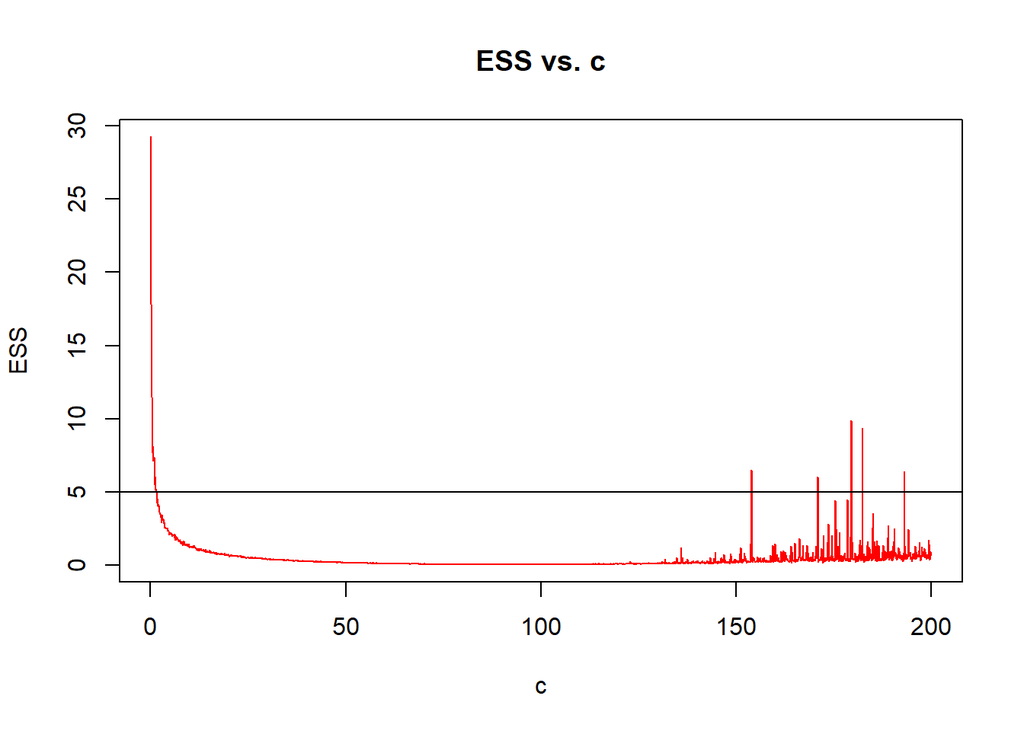

```r
# X is the data, res is the number of monte carlo samples,
# C is the tuning parameter for the g distribution
IS <- function(X, C, res)
{
# sample size
n <- length(X)
# log posterior derived above
log.posterior <- function(t) (sum(X)+4)*log(t) + (n*(10-mean(X))-2)*log(1-t)
# log trial density, g
log.g <- function(t) dbeta(t,C*mean(X),C*(10-mean(X)), log=TRUE)
# log importance function
log.w <- function(t) log.posterior(t) - log.g(t)
# generate from the trial distribution
U <- rbeta(res, C*mean(X), C*(10-mean(X)))
# calculate the list of log.w values
LP <- log.w(U)
# factor out the largest value to prevent numerical underflow
w <- max(LP)
LP <- LP - w
# importance sampling estimate
I <- mean( exp(LP)*U )/mean(exp(LP))
# calculate ESS
ESS <- mean( ( (exp(LP)/mean(exp(LP))) - 1)^2 )
# calculate s.e. of the IS estimate
Z = exp(LP)/mean(exp(LP))
sig.sq <- (1/res)*sum( (Z-I)^2 )
se <- sqrt( sig.sq/res )
# return the 95 percent confidence interval for the estimate
return(c(I - 1.96*se, I + 1.96*se, ESS))
}
# Generate 100 binomial(10,.4) random variables
X = rbinom(100, 10, .4)
## calculate ESS and var(E(theta|X))
## for a grid of values for alpha
const <- seq(.1, 200, length=2000)
A <- matrix(0, 2000, 2)
for(j in 1:2000)
{OUT <- IS(X, const[j], 1000)
ESS <- OUT[3]
V <- (OUT[2]-OUT[1])/3.92
A[j,] <- c(ESS, V)
}
# see where ESS is low enough
plot(const, A[,1], ylab="ESS", xlab="c", main="ESS vs. c", col=2, type="l")
abline(h=5)
```

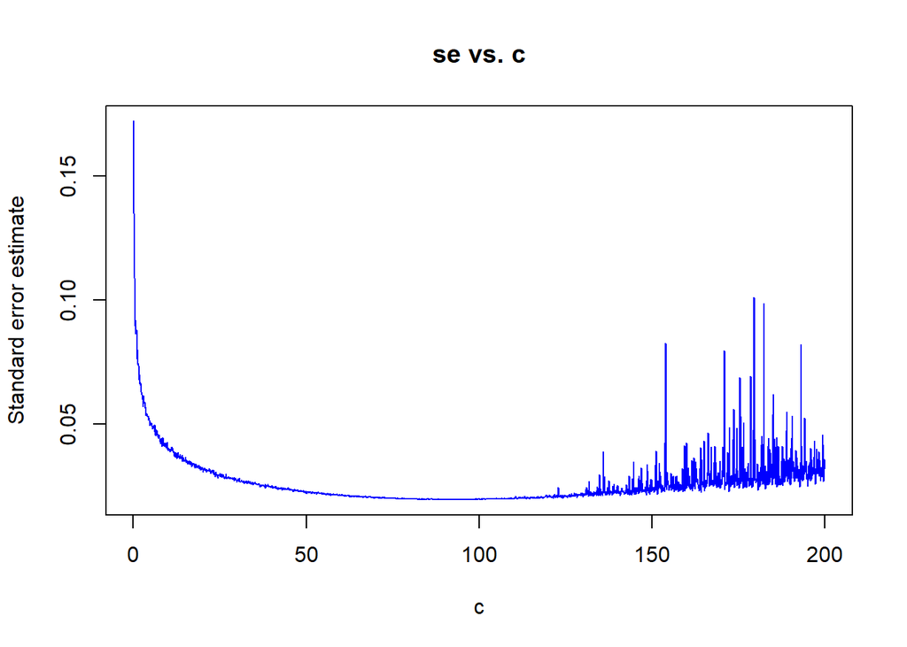

```r
# standard error estimates
plot(const, A[,2], xlab="c", ylab="Standard error estimate", main="se vs. c", col=4, type="l")
```

```r
# The final confidence interval
IS(X, const[which.min(A[,2])], 1000)[1:2]
```

```
## [1] 0.3726 0.4504
```

### 4.2 Reference:

http://dept.stat.lsa.umich.edu/~jasoneg/Stat406/lab7.pdf

## Problem 5-Optimization (Jiangong Li):

Consider Poisson log-likelihood function, which is given by

$L(x|\mu)=\sum{y_i\ln(\mu)}-n\mu-\sum{\ln(y_i!)}$.

The last term can be ignored since theit don’t inlcude the parameter mu is

$L(x|\mu)=\sum{y_i\ln(\mu)}-n\mu$

```r
poisson.lik<-function(mu,y){
n<-length(y)
logl<-sum(y)*log(mu)-n*mu
return(-logl)
}
```

### 5.1 Use built-in function to find optimal solution:

```r
lambda=2
data=rpois(100,lambda)
results=optim(1,poisson.lik,y=data)
print("optimal points:")
```

```
## [1] "optimal points:"
```

```r
results$par
```

```
## [1] 1.84
```

```r
print("counts to converge:")
```

```
## [1] "counts to converge:"
```

```r
results$counts
```

```
## function gradient
##       26       NA
```

### 5.2 Use BFGS method to find optimal solution:

```r
results=optim(1,poisson.lik,y=data,method="BFGS")
print("optimal points:")
```

```
## [1] "optimal points:"
```

```r
results$par
```

```
## [1] 1.84
```

```r
print("counts to converge:")
```

```
## [1] "counts to converge:"
```

```r
results$counts
```

```
## function gradient
##       23        6
```

### 5.3 Reference:

[Maximum Likelihood Programming in R](https://www.ime.unicamp.br/~cnaber/optim_1.pdf)